# Analysis of Phage Display Protease and Supernatant Screens

# Protease Mixture Deconvolution with CibersortX and EPIC

Based on prior analyses, peptide profiles were identified to broadly capture the proteolytic signatures of different proteases and mixture conditions. However, major challenges remain in deconvolution and differentiating proteases within mixtures objectively.

Drawing upon developed Bulk RNA-seq Deconvolution methods, the peptide dataset of proteases and mixtures were applied towards this purpose. To ensure robustness, 2 different algorithms CibersortX and EPIC, were used.

https://cibersortx.stanford.edu/ https://epic.gfellerlab.org/

A comprehensive protease reference profile was constructed, using the normalized counts of all cleaved peptides in each protease condition. This profile was directly applied towards analyzing the separate mixture dataset of activated neutrophils, determining estimates of proteolytic activity levels for each protease.

Reference Profile 1) 3 neutrophil serine proteases, 2 phage controls, ADAMTS13, thrombin

The protease profile consisted of cleaved/released phages in 7 conditions: 3 neutrophil serine proteases (cathepsin G, elastase, hPR3), no protease (baseline phage release), FLAG peptide elution (unselected phage library), and 2 blood proteases (ADAMTS13, thrombin).

The 2 phage controls were included as a reference for phage library background and noise. The 2 blood proteases were included to provide a control against false signals, since both have no expected activity/presence in neutrophil supernatants.

Data for ADAMTS13 and thrombin were sourced from a 6-mer NNK phage display library with a similar composition by Kretz et al., 2018, with 6-mers split into 5-mers for the current analysis.

https://www.nature.com/articles/s41598-018-21021-9

## Deconvolution: Generation of Protease Reference Profile

A protease reference profile was constructed based on DESeq2-normalized counts of cleaved peptides across the 7 conditions. Counts data from neutrophil proteases, phage controls and ADAMTS13/thrombin were merged and subsequently normalized via DESeq2.

Standard settings were used, with quantile normalization and a barcode peptide range of 2000-3000 per condition applied for generating the protease signature matrix in CibersortX. B-mode batch correction was enabled in CibersortX when thrombin and ADAMTS13 were tested for correction.

```r
#Reference Profile 1
ADAMTS13_thrombin <- read.csv("ADAMTS13_thrombin_5mer_data.csv", header=TRUE,row.names=1)
ADAMTS13_thrombin$peptide <- rownames(ADAMTS13_thrombin)
mergedData <- protease_counts
mergedData$peptide <- rownames(mergedData)
mergedData <- merge(mergedData, ADAMTS13_thrombin, by = "peptide", all = TRUE)
mergedData[is.na(mergedData)] <- 0
rownames(mergedData) <- mergedData$peptide
mergedData <- mergedData[, -1]

ADAMTS13_thrombin_conditions = c("cathepsin G","elastase","hPR3","no protease", "ADAMTS13", "thrombin")
ADAMTS13_thrombin_replicates = c("C1", "C2", "C3", "E1", "E2", "E3", "H1", "H2", "H3", "V1", "V2", "V3", "N1", "N2", "N3", "AD1", "AD2", "AD3", "AD4", "T1", "T2", "T3", "T4")
ADAMTS13_thrombin_col = c("cathepsin G","cathepsin G","cathepsin G", "elastase","elastase","elastase","hPR3","hPR3","hPR3","no protease", "no protease", "no protease", "FLAG","FLAG","FLAG", "ADAMTS13", "ADAMTS13", "ADAMTS13", "ADAMTS13", "thrombin", "thrombin", "thrombin", "thrombin")
ADAMTS13_thrombin_colname = c("cathepsin G 1","cathepsin G 2","cathepsin G 3","elastase 1","elastase 2","elastase 3","hPR3 1","hPR3 2","hPR3 3","no protease 1", "no protease 2", "no protease 3", "FLAG 1","FLAG 2","FLAG 3", "ADAMTS13 1", "ADAMTS13 2", "ADAMTS13 3", "ADAMTS13 4", "thrombin 1", "thrombin 2", "thrombin 3", "thrombin 4")
control = "FLAG"

data_NS <- subset(mergedData, grepl("X", row.names(mergedData))==FALSE)
countData <- as.matrix(data_NS)
colData <- data.frame(condition=factor(ADAMTS13_thrombin_col))
dds=DESeqDataSetFromMatrix(countData, colData, formula(~ condition))
dds$condition <- relevel(dds$condition, ref = "FLAG")
keep <- rowSums(counts(dds)) >= 10
dds_ADAMTS13_thrombin <- dds[keep,]
dds_ADAMTS13_thrombin=DESeq(dds_ADAMTS13_thrombin)
saveRDS(dds_ADAMTS13_thrombin, file = paste0("ADAMTS13_thrombin_dds_object.rds"))
```

ADAMTS13_thrombin

## Deconvolution: Protease Counts Data Preparation

Following DESeq2 Counts Normalization, input data for CibersortX and EPIC was prepared and formatted. Due to memory limitations on processing by EPIC/CibersortX, a row sum filter of 140 was applied to remove low count peptides, taking out 16.5% peptides.

```r
ADAMTS13_thrombin_matrix <- as.data.frame(counts(dds_ADAMTS13_thrombin, normalized = TRUE, replaced = FALSE))
row_names <- as.list(rownames(ADAMTS13_thrombin_matrix))
ADAMTS13_thrombin_matrix$condition <- row_names
ADAMTS13_thrombin_matrix <- ADAMTS13_thrombin_matrix[, c(ncol(ADAMTS13_thrombin_matrix), 1:(ncol(ADAMTS13_thrombin_matrix)-1))]
colnames(ADAMTS13_thrombin_matrix) <- c("peptide", as.list(ADAMTS13_thrombin_col))
nrow(ADAMTS13_counts)

ADAMTS13_counts <- as.data.frame(counts(dds_ADAMTS13_thrombin, replaced = FALSE))
ADAMTS13_counts <- ADAMTS13_counts[apply(ADAMTS13_counts, 1, function(row) sum(row) < 140), ]
ADAMTS13_thrombin_matrix <- ADAMTS13_thrombin_matrix[!rownames(ADAMTS13_thrombin_matrix) %in% rownames(ADAMTS13_counts), ]
ADAMTS13_thrombin_matrix <- as.matrix(ADAMTS13_thrombin_matrix)
write.table(ADAMTS13_thrombin_matrix, file = paste0("filtered_protease_ref_ADAMTS13_thrombin.txt"), sep = "\t", row.names = FALSE)
```

### Deconvolution: Mixture Counts Data Preparation

The bulk mixture dataset, which consists of the activated neutrophil supernatant across different conditions, was generated based on normalized cleaved peptide counts. Due to memory limitations on processing by EPIC/CibersortX, a row sum filter of 30 was applied.

```r
#Bulk Mixture Profile
mixture_matrix <- as.data.frame(counts(dds_mixture, normalized = TRUE, replaced = FALSE))
row_names <- as.list(rownames(mixture_matrix))
mixture_matrix$condition <- row_names
mixture_matrix <- mixture_matrix[, c(ncol(mixture_matrix), 1:(ncol(mixture_matrix)-1))]
colnames(mixture_matrix) <- c("peptide", as.list(mixture_col))
mixture_matrix <- as.matrix(mixture_matrix)
write.table(mixture_matrix, file = paste0("supernatant_mixture.txt"), sep = "\t", row.names = FALSE)

lowcounts <- as.data.frame(counts(dds_mixture, replaced = FALSE))
lowcounts <- lowcounts[apply(lowcounts, 1, function(row) sum(row) < 30), ]
mixture_matrix_filtered <- mixture_matrix[!rownames(mixture_matrix) %in% rownames(lowcounts), ]
mixture_matrix_filtered <- as.matrix(mixture_matrix_filtered)
write.table(mixture_matrix_filtered, file = paste0("filtered_supernatant_mixture.txt"), sep = "\t", row.names = FALSE)
```

## Deconvolution of the Neutrophil Supernatant Mixture

## Deconvolution Results from CibersortX

For CibersortX, a protease signature matrix was first created based on the reference profile, independently from mixture data. This matrix extracted signature peptides that characterize the presence of tested proteases/conditions.

### Parameters for Creation of the Protease Signature Matrix: (‘Signature Matrix Creation’)

Default (kappa = 999, q-value = 0.01, sampling = 0.5, min expression = 1)

Quantile Normalization enabled

Min-Max Barcode Peptides per Condition: adjusted for experiment complexity (2000-3000)

This signature matrix was applied towards the bulk mixture to analyze protease composition within each neutrophil supernatant.

### Parameters for Mixture Deconvolution: (’Impute Cell Fractions, Absolute Mode)

Default (batch correction disabled, quantile normalization disabled, permutations = 1)

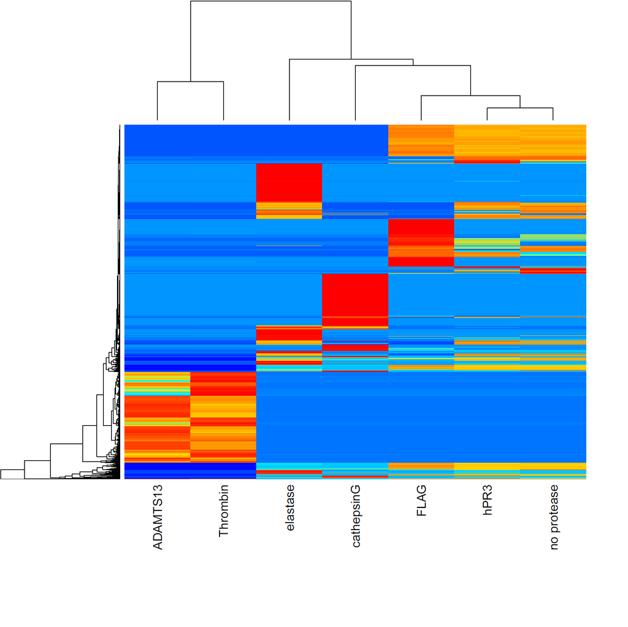

[figure not shown]

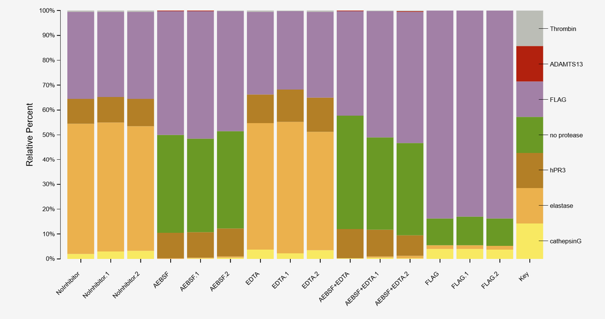

CibersortX MEROPs Results

Total Peptides included in the Protease Signature Matrix: 11221

## Deconvolution Results from EPIC

In contrast to CibersortX, EPIC does not require the prior generation of a specific signature matrix. The protease reference profile, of normalized cleaved peptides, was used directly for deconvolution analysis onto the mixture reference profile.

A signature peptide list for EPIC’s analyses was obtained from the intersection between protease and mixture peptides (138224 peptides).

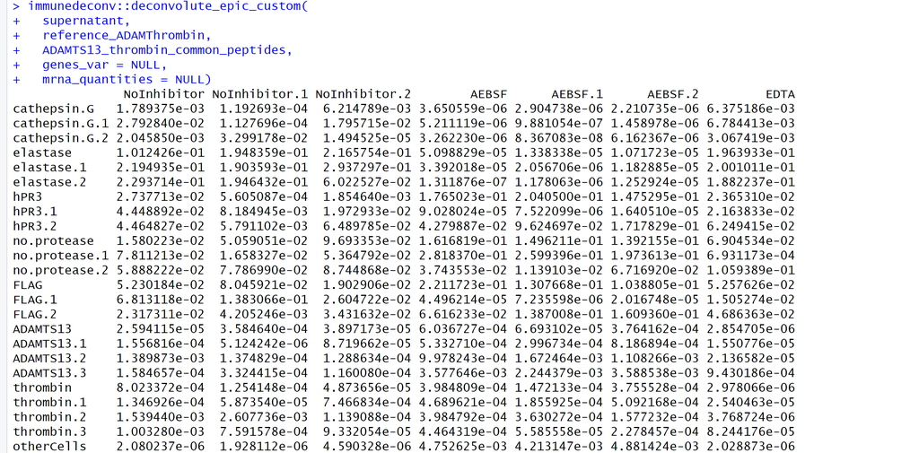

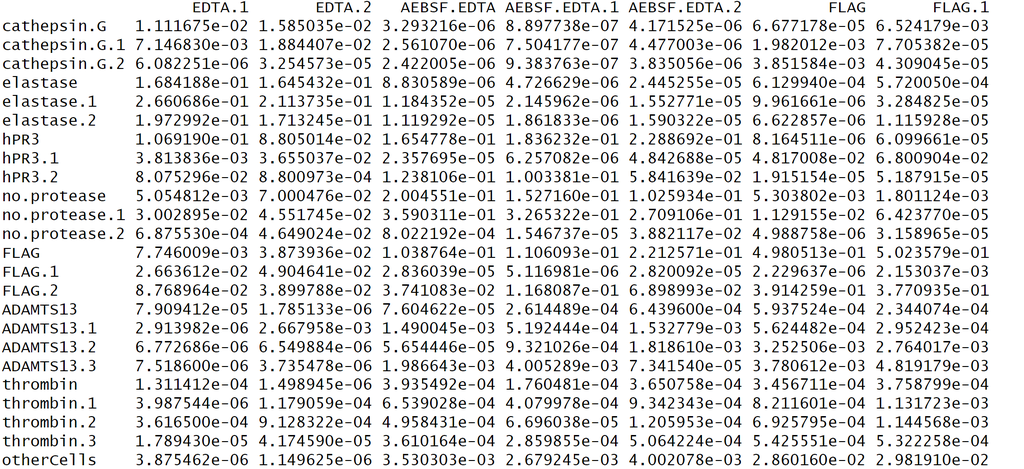

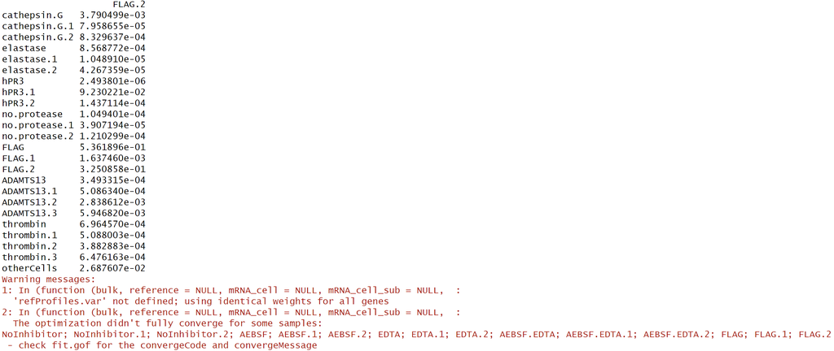

EPIC MEROPs results

```r
ADAMTS13_thrombin_common_peptides <- intersect(rownames(ADAMTS13_thrombin_matrix), rownames(mixture_matrix_filtered))
write.table(ADAMTS13_thrombin_common_peptides, file="ADAMTS13_thrombin_signature_peptides.txt", row.names = FALSE, col.names = FALSE, quote = FALSE)

supernatant <- read.table(file = "filtered_supernatant_mixture.txt", header=TRUE,row.names=1)
reference_ADAMThrombin <- read.table(file = "filtered_protease_ref_ADAMTS13_thrombin.txt", header=TRUE,row.names=1)
immunedeconv::deconvolute_epic_custom(
  supernatant,
  reference_ADAMThrombin,
  ADAMTS13_thrombin_common_peptides,
  genes_var = NULL,
  mrna_quantities = NULL)
```

# Data from CibersortX Results

CibersortX estimates of proteolytic activity levels across mixture conditions were visualized with barplots and heatmaps. Relative percentages depicted activity as part of 100%, while absolute scores depicted unstandardized levels of activity/presence.

## CibersortX: Generation of Figures for Percentages

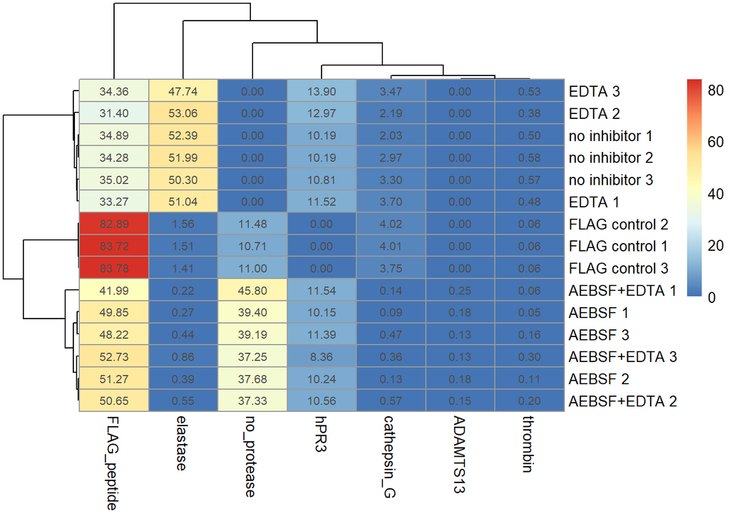

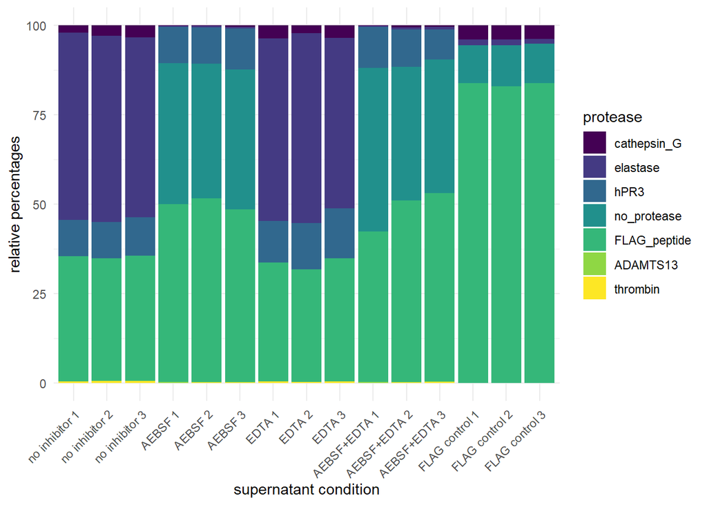

## CibersortX: Generation of Figures for Absolute Scores

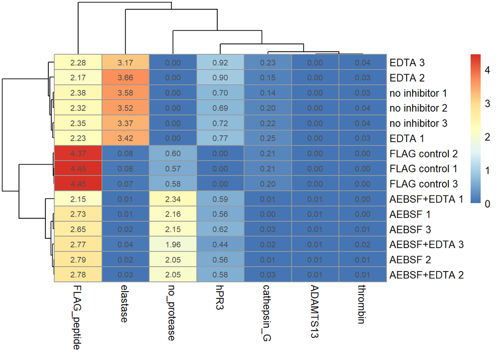

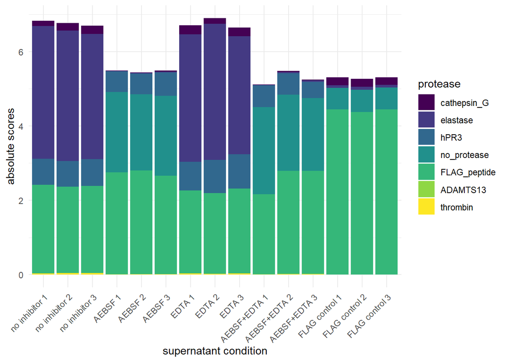

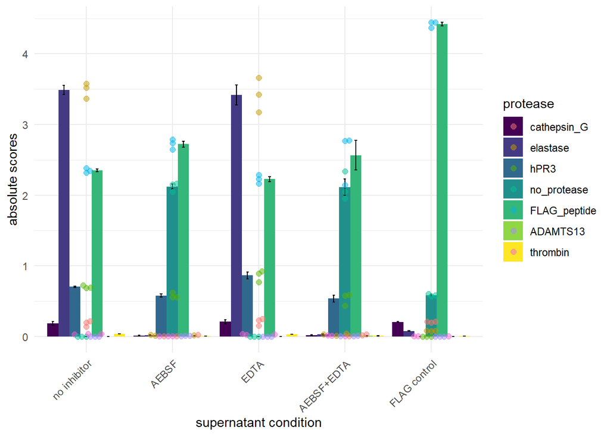

### Statistical Comparisons

Statistical comparisons using a Kruskal-Wallis test for differences and 2-sample t-test between conditions was performed for the absolute scores. Results were visualized with boxplots.

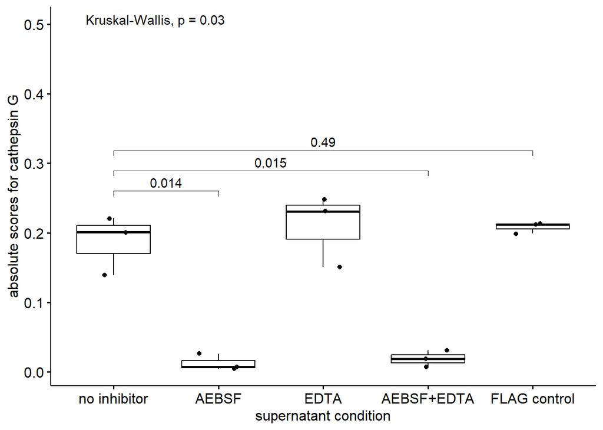

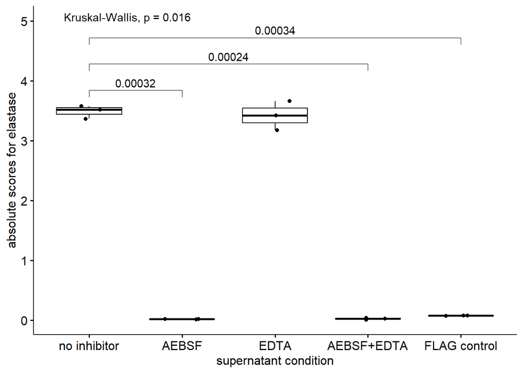

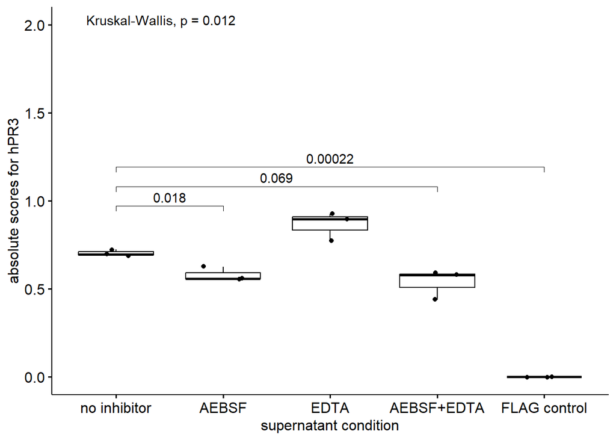

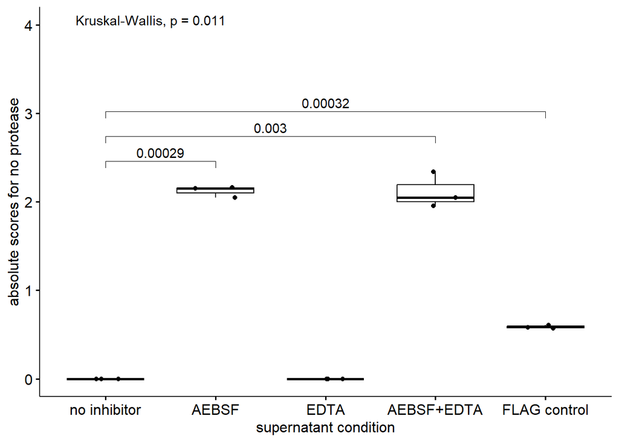

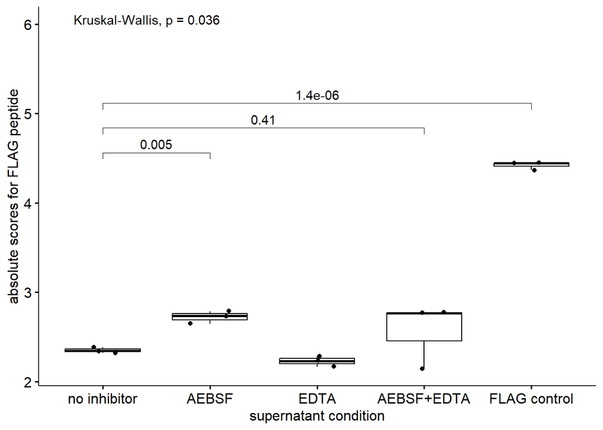

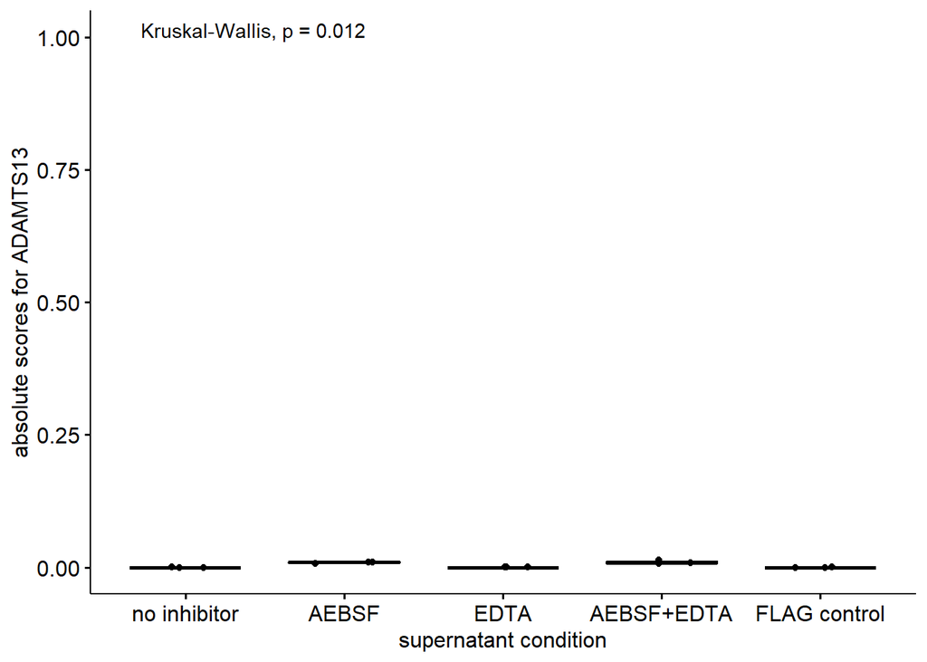

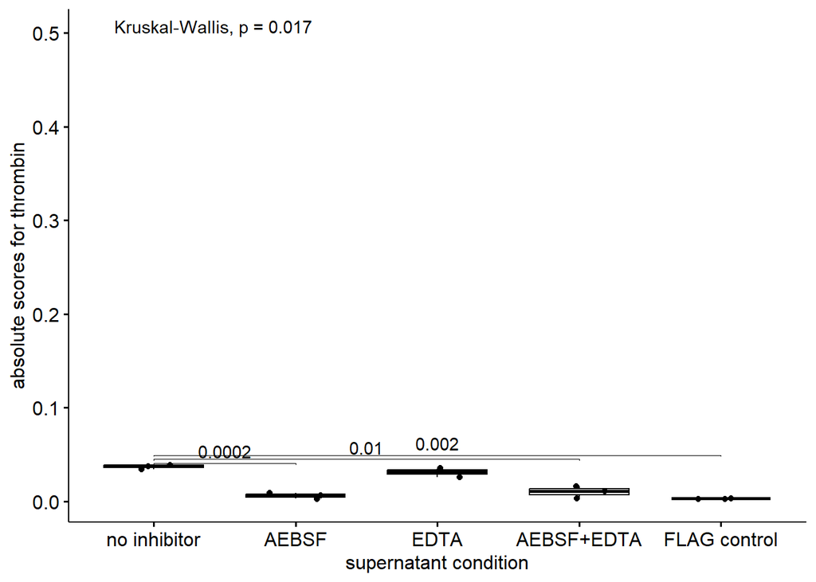

```r
conditions <- c("cathepsin_G", "elastase", "hPR3", "no_protease", "FLAG_peptide", "ADAMTS13", "thrombin")
names = c("cathepsin G", "elastase",  "hPR3", "no protease", "FLAG peptide", "ADAMTS13", "thrombin")
condition_comparisons <- list( c("no inhibitor", "AEBSF"), c("no inhibitor", "AEBSF+EDTA"), c("no inhibitor", "FLAG control") )
graph_scale = c(0.5, 5, 2, 4, 6, 1, 0.5) #scale graph to fit y-axis

for(i in 1:length(conditions)){
  box_plot <- ggboxplot(cibersort_absolute_ADAMThrombin, x = "Condition", y = conditions[i], add = "jitter") +
  labs(x = "supernatant condition", y = paste0("absolute scores for ", names[i])) +
  stat_compare_means(comparisons = condition_comparisons, method = "t.test") +
  stat_compare_means(label.y = graph_scale[i])
  show(box_plot)
}
```

# Data from EPIC Results

EPIC estimates of proteolytic activity levels across mixture conditions were visualized with barplots and heatmaps. Relative percentages depicted activity as part of 100%. Absolute scores were not reported by EPIC.

## EPIC: Generation of Figures for Percentages

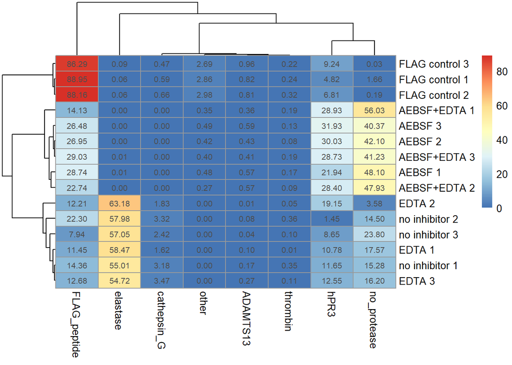

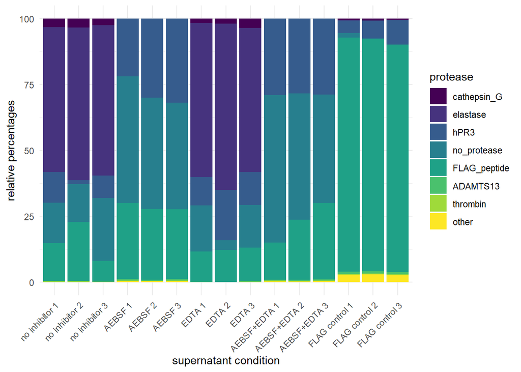

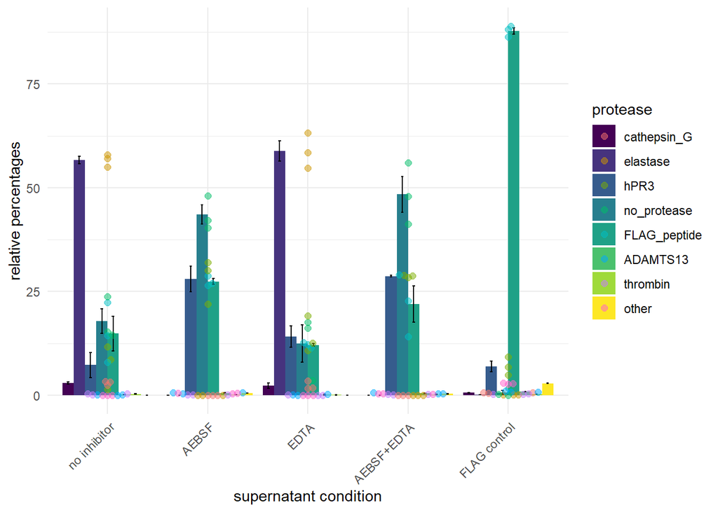

### Statistical Comparisons

Statistical comparisons using a Kruskal-Wallis test for differences and 2-sample t-test between conditions was performed for the percentages.

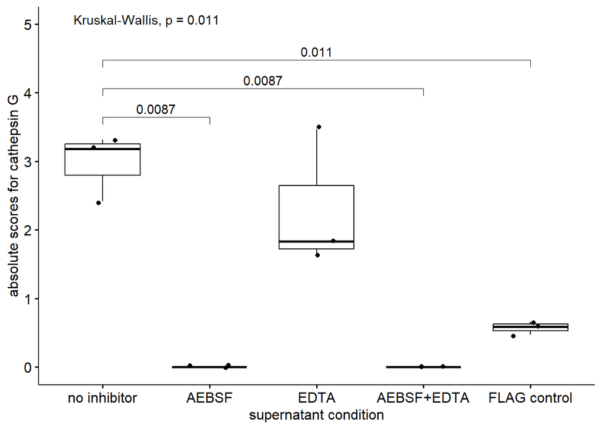

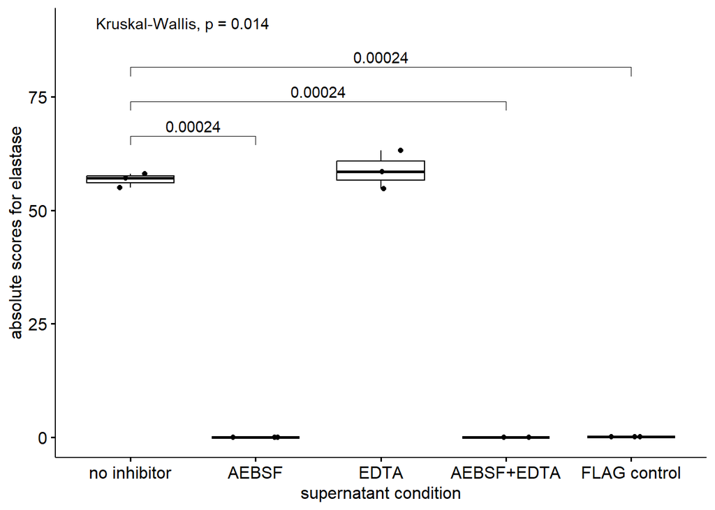

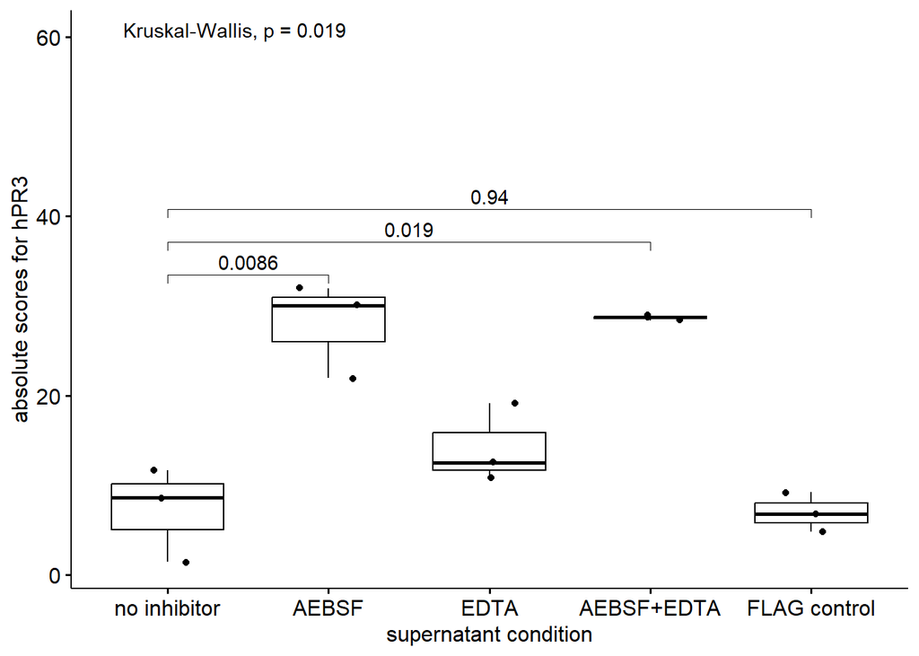

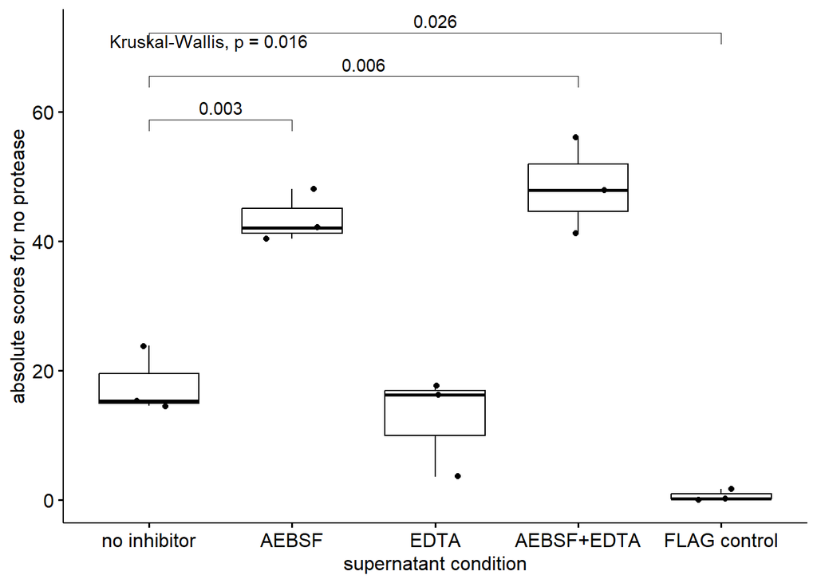

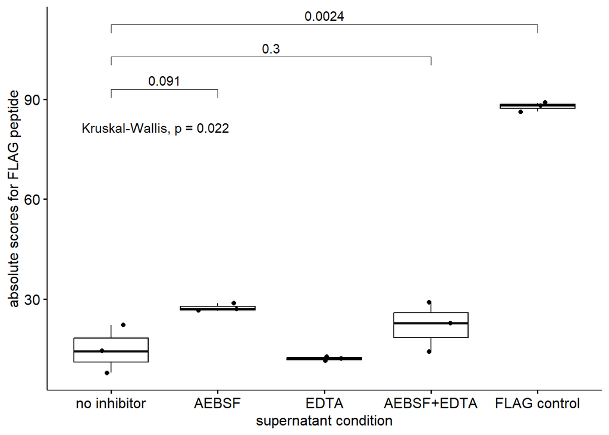

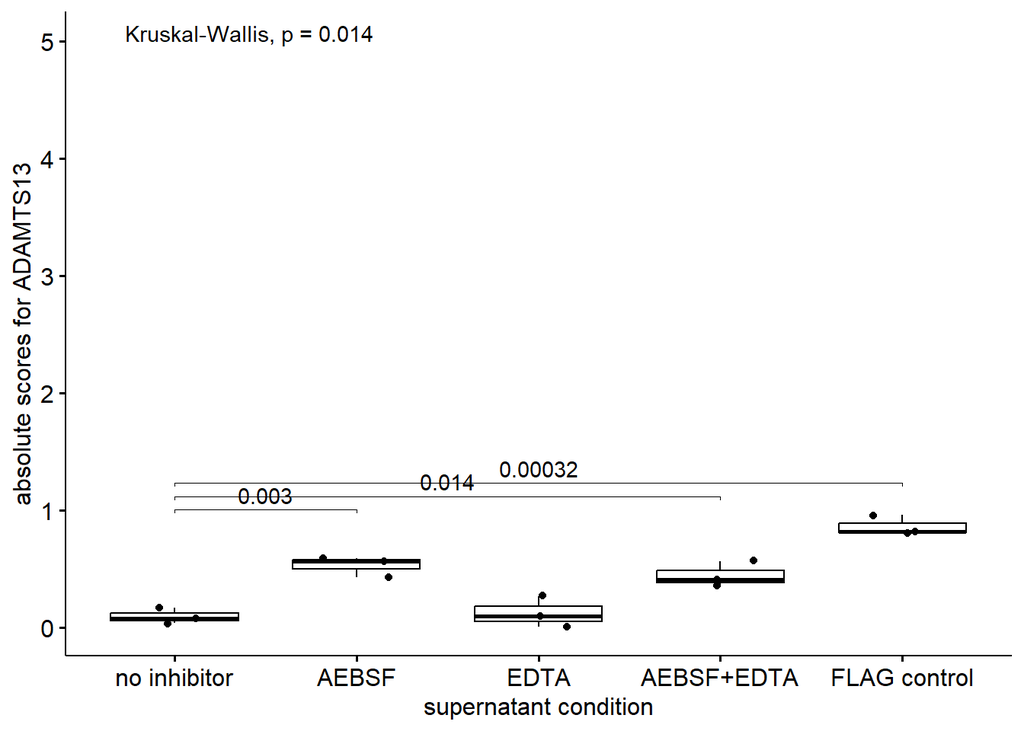

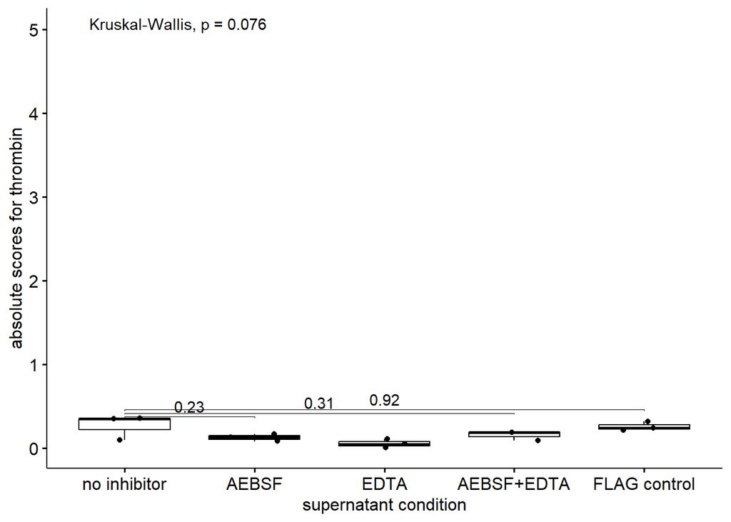

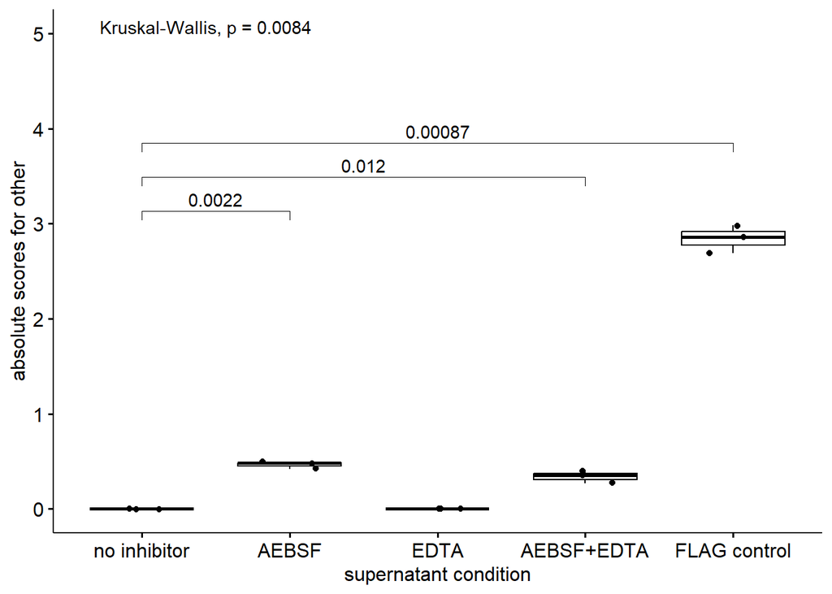

```r
conditions <- c("cathepsin_G", "elastase", "hPR3", "no_protease", "FLAG_peptide", "ADAMTS13", "thrombin", "other")
names = c("cathepsin G", "elastase","hPR3","no protease", "FLAG peptide", "ADAMTS13", "thrombin", "other")
condition_comparisons <- list( c("no inhibitor", "AEBSF"), c("no inhibitor", "AEBSF+EDTA"), c("no inhibitor", "FLAG control") )
graph_scale = c(5, 90, 60, 70, 80, 5, 5, 5) #scale graph to fit y-axis

for(i in 1:length(conditions)){
  box_plot <- ggboxplot(epic_percentage_ADAMThrombin, x = "Condition", y = conditions[i], add = "jitter") +
  labs(x = "supernatant condition", y = paste0("absolute scores for ", names[i])) +
  stat_compare_means(comparisons = condition_comparisons, method = "t.test") +
  stat_compare_means(label.y = graph_scale[i])
  show(box_plot)
}
```

# Repeated Deconvolution Analyses with different protease references

To test the robustness of the algorithms and obtained deconvolution estimates, CibersortX and EPIC were repeated with different protease reference profiles. Due to concerns specified in the manuscript, a trial was conducted with hPR3 excluded.

Reference Profile 2) 3 neutrophil serine proteases, 2 phage controls Reference Profile 3) cathepsin G, elastase, 2 phage controls (without hPR3)

## Deconvolution: Protease Reference Matrix

A protease reference profile of the 3 neutrophil serine proteases and 2 phage controls was constructed. This was used as input for CibersortX to construct the protease signature matrix.

### CibersortX Parameters for Protease Signature Matrix:

Default (kappa = 999, q-value = 0.01, sampling = 0.5, min expression = 1)

Quantile Normalization enabled

Min-Max Barcode Peptides per Condition: adjusted for experiment complexity (500-1000 for all proteases, 2000-3000 without hPR3)

```r
#Reference Profile 2
protease_matrix <- as.data.frame(counts(dds_protease, normalized = TRUE, replaced = FALSE))
row_names <- as.list(rownames(protease_matrix))
protease_matrix$condition <- row_names
protease_matrix <- protease_matrix[, c(ncol(protease_matrix), 1:(ncol(protease_matrix)-1))]
colnames(protease_matrix) <- c("peptide", as.list(protease_col))
protease_matrix <- as.matrix(protease_matrix)
write.table(protease_matrix, file = paste0("protease_ref.txt"), sep = "\t", row.names = FALSE)
```

```r
#Reference Profile 3
protease_matrix_nohPR3 <- protease_matrix[, !grepl("^hPR3", colnames(protease_matrix))]
protease_matrix_nohPR3 <- as.matrix(protease_matrix_nohPR3)
write.table(protease_matrix_nohPR3, file = paste0("protease_ref_hPR3_excluded.txt"), sep = "\t", row.names = FALSE)
```

Total Peptides included in Signature Matrix: 6259 (All proteases), 6166 (hPR3 excluded)

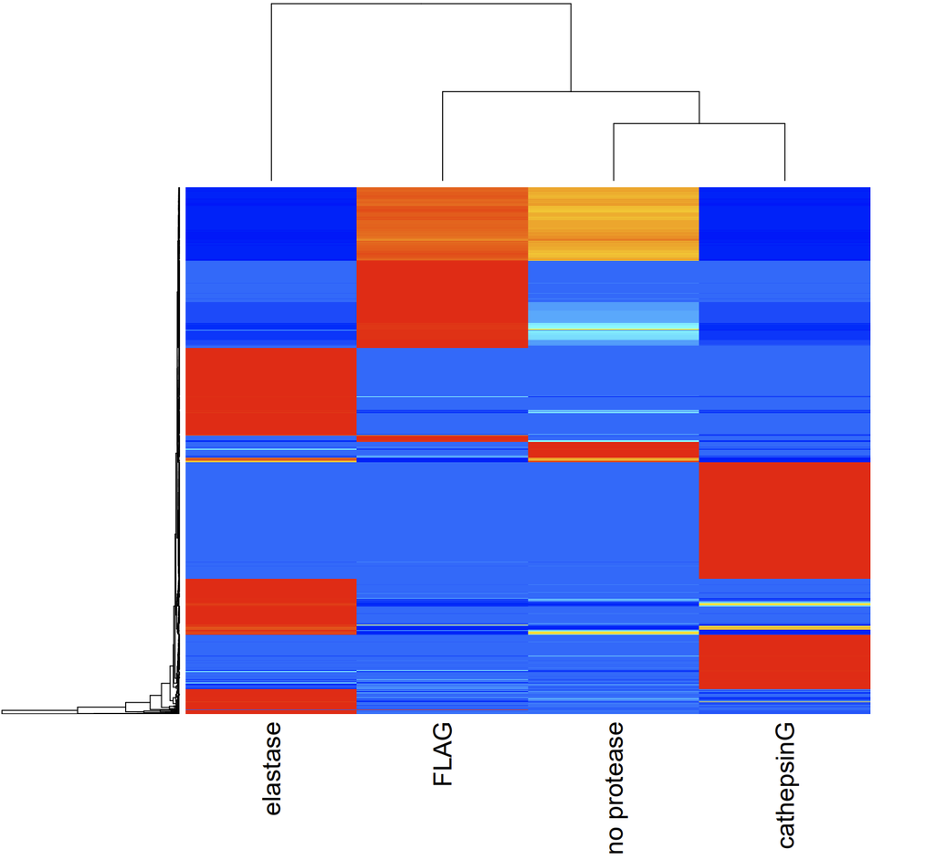

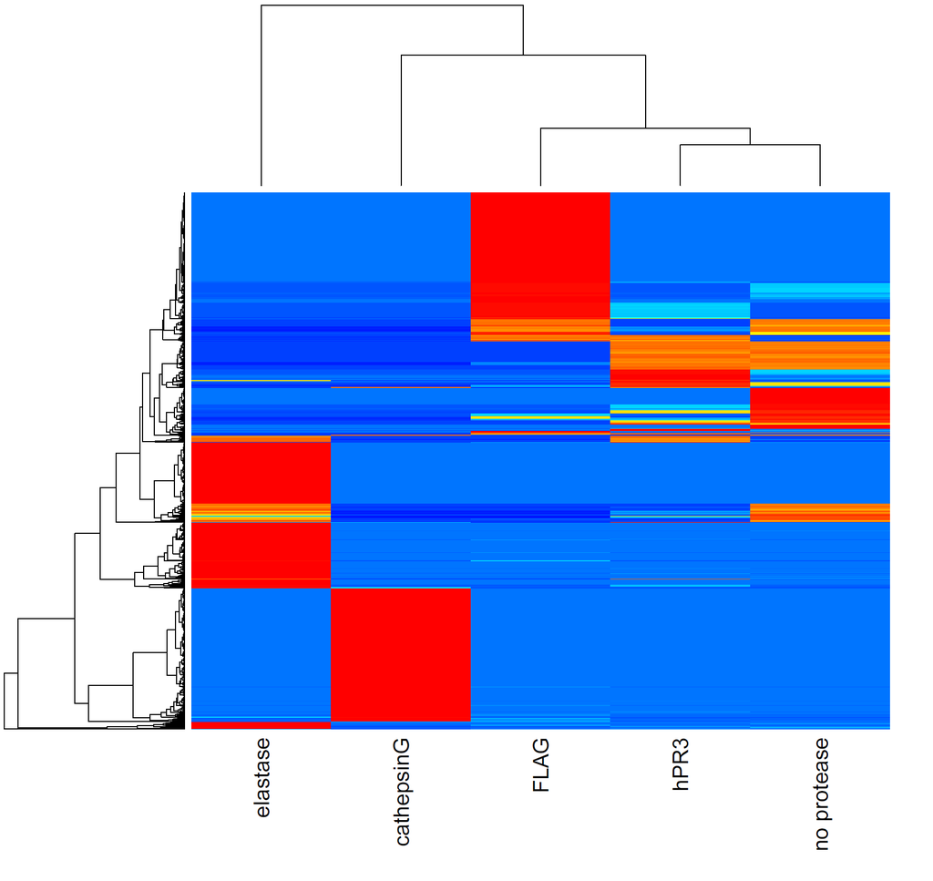

protease Signature Matrices without (left) and with (right) the inclusion of hPR3

### CibersortX Parameters for Mixture Deconvolution:

Protease composition analysis was based on default parameters: Default (Batch Correction disabled, Quantile Normalization disabled, Permutations = 1)

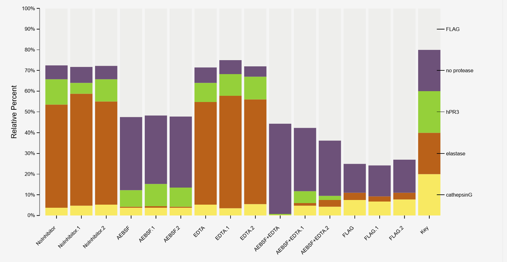

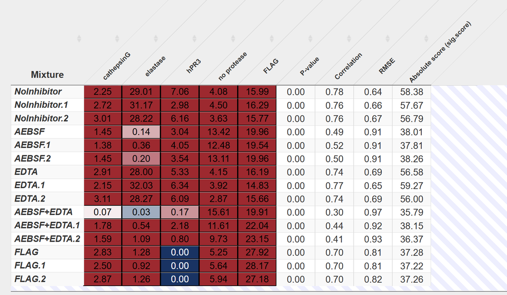

protease Percentages (left) and absolute scores (right) for all proteases

[figure not shown]

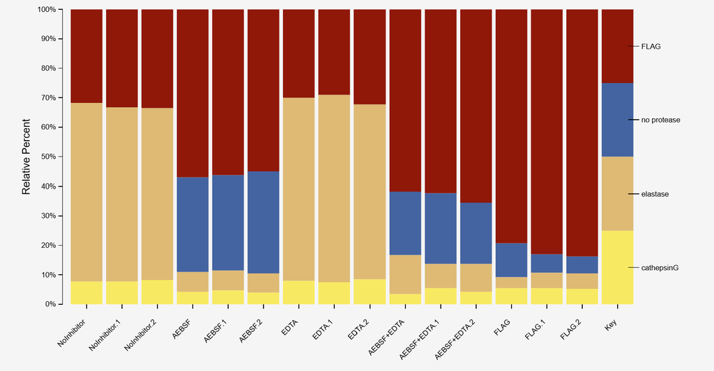

### EPIC Parameters for Protease Reference and Deconvolution:

A signature peptide list for EPIC’s analyses was obtained from the intersection between protease and mixture peptides (203974 peptides).

Due to memory limitations on processing by EPIC , a row sum filter of 30 was applied.

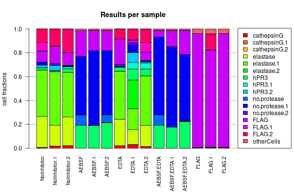

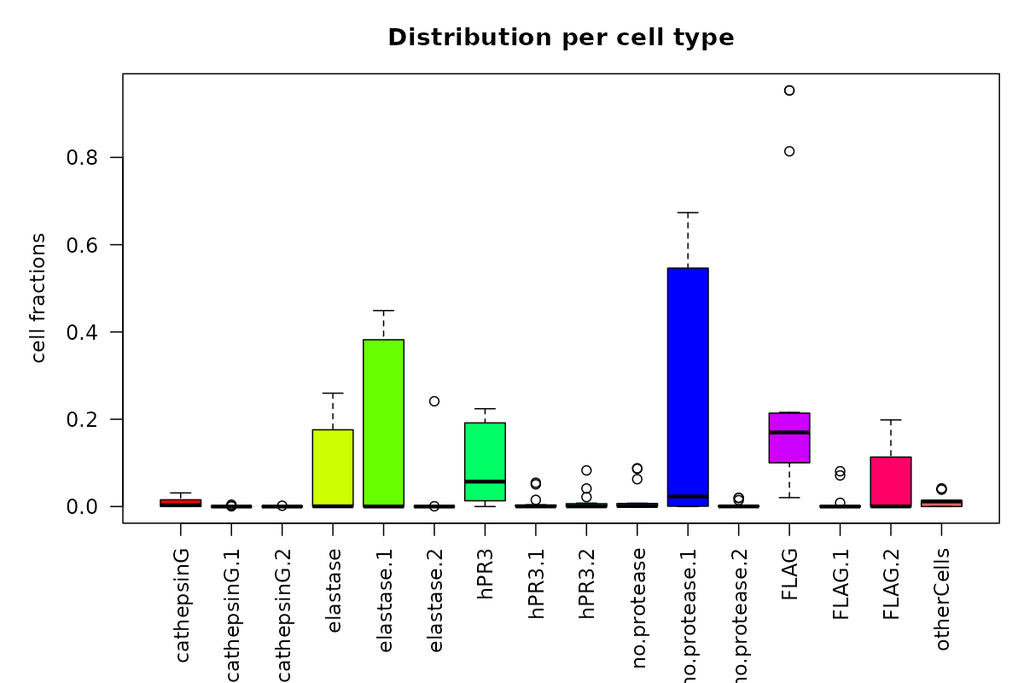

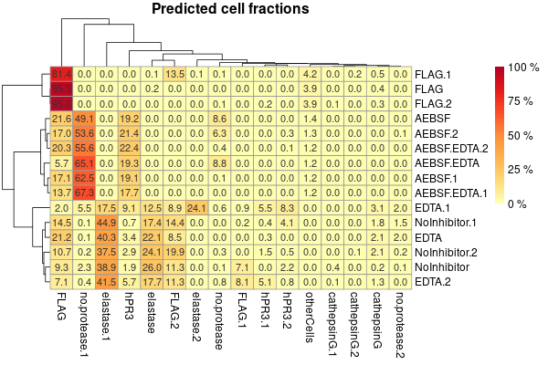

EPIC Results with all proteases

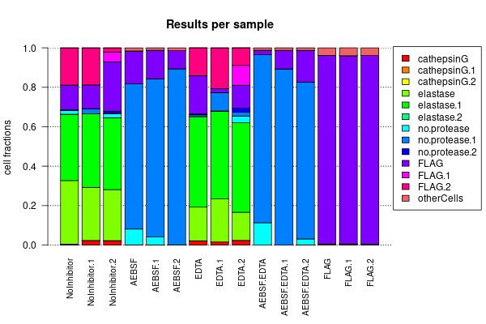

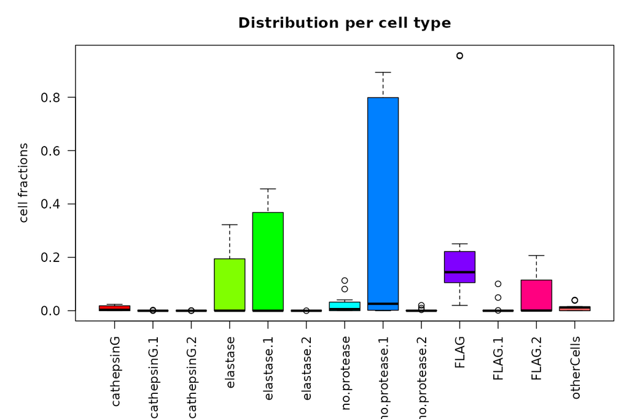

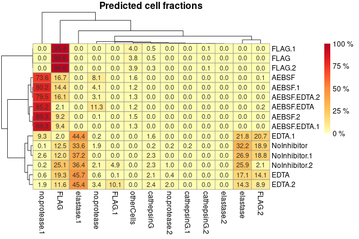

EPIC Results without hPR3

```r
lowcounts <- as.data.frame(counts(dds_protease, replaced = FALSE))
lowcounts <- lowcounts[apply(lowcounts, 1, function(row) sum(row) < 30), ]
matrix_filtered <- protease_matrix[!rownames(protease_matrix) %in% rownames(lowcounts), ]
matrix_filtered <- as.matrix(matrix_filtered)

matrix_filtered_nohPR3 <- matrix_filtered[, !grepl("^hPR3", colnames(matrix_filtered))]
matrix_filtered_nohPR3 <- as.matrix(matrix_filtered_nohPR3)
write.table(matrix_filtered, file = paste0("filtered_protease_ref.txt"), sep = "\t", row.names = FALSE)
write.table(matrix_filtered_nohPR3, file = paste0("filtered_protease_ref_nohPR3.txt"), sep = "\t", row.names = FALSE)

common_peptides <- intersect(rownames(matrix_filtered), rownames(mixture_matrix_filtered))
write.table(common_peptides, file="signature_peptides.txt", row.names = FALSE, col.names = FALSE, quote = FALSE)
```

# Data from CibersortX Results: all neutrophil serine proteases (profile 2)

To examine the estimated protease % composition and absolute presence score across mixture conditions from CibersortX, barplots and heatmaps were generated.

## CibersortX: Generation of Figures for Percentages

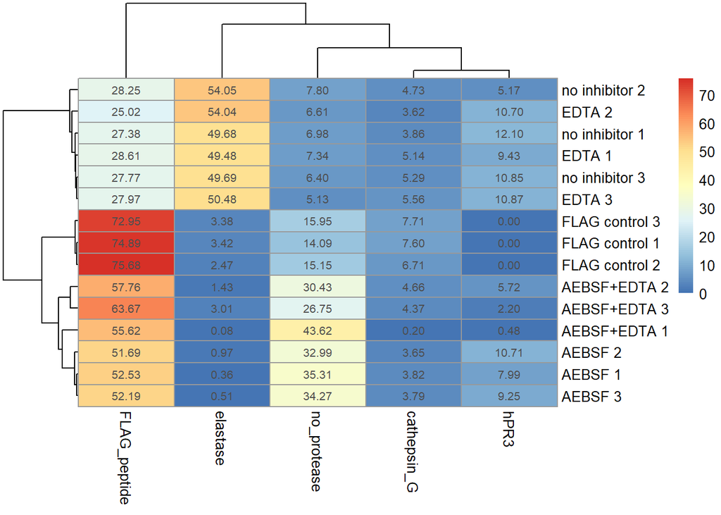

```r
percentage_data <- cibersort_percentage %>%
  mutate(Condition = paste0(Condition, " ", (row_number()-1)%%3 + 1))
rownames(percentage_data) <- percentage_data[, 1]
heatmap_data <- percentage_data[, -1]
pheatmap(heatmap_data, display_numbers = TRUE)
```

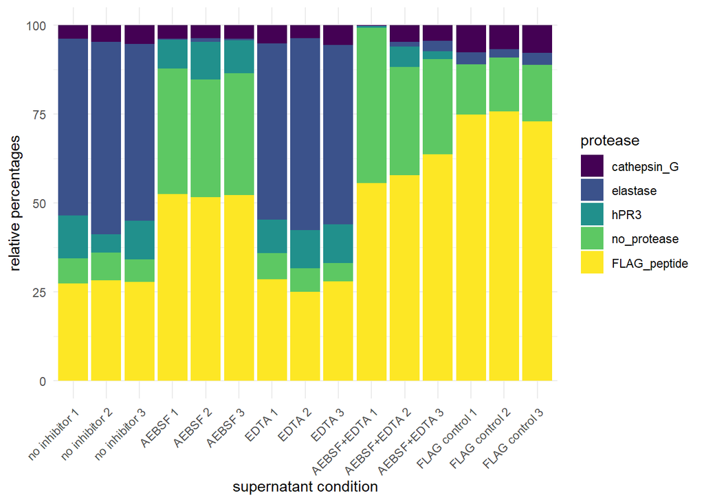

```r
barplot_data <- reshape2::melt(percentage_data, id.vars = "Condition")
ggplot(barplot_data, aes(x = fct_inorder(Condition), y = value, fill = variable)) + geom_bar(stat = "identity") + labs(x = "supernatant condition", y = "relative percentages", fill = "protease") + scale_fill_viridis_d()+ theme_minimal() + theme(axis.text.x = element_text(angle = 45, hjust = 1))
```

## CibersortX: Generation of Figures for Absolute Scores

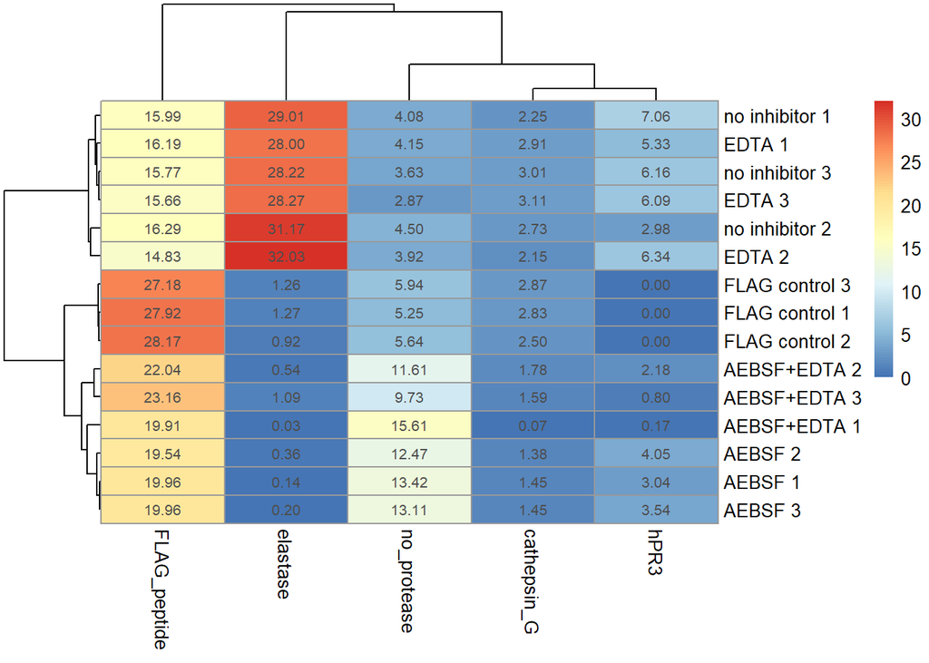

```r
absolute_data <- cibersort_absolute %>%
  mutate(Condition = paste0(Condition, " ", (row_number()-1)%%3 + 1))
barplot_data <- reshape2::melt(absolute_data, id.vars = "Condition")
rownames(absolute_data) <- absolute_data[, 1]
pheatmap(absolute_data[,-1], display_numbers = TRUE)
```

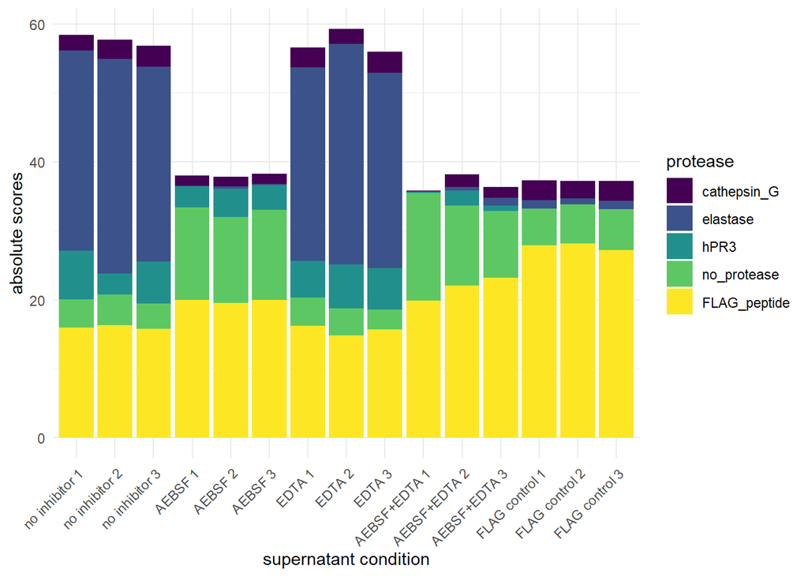

```r
ggplot(barplot_data, aes(x = fct_inorder(Condition), y = value, fill = variable)) + geom_bar(stat = "identity") + labs(x = "supernatant condition", y = "absolute scores", fill = "protease") + scale_fill_viridis_d()+ theme_minimal() + theme(axis.text.x = element_text(angle = 45, hjust = 1))
```

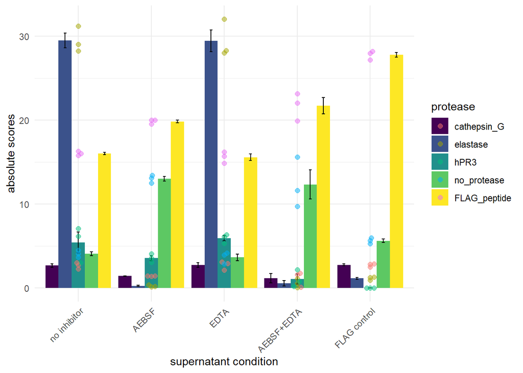

```r
barplot_data <- cibersort_absolute %>%
  pivot_longer(-Condition, names_to = "protease", values_to = "Absolute_Score")
barplot_data <- barplot_data %>%
mutate(protease = factor(protease, levels = c("cathepsin_G", "elastase", "hPR3", "no_protease", "FLAG_peptide")))
ggplot(barplot_data, aes(x = fct_inorder(Condition), y = Absolute_Score, fill = protease)) +
  geom_bar(stat = "summary", fun = "mean", position = position_dodge(width = 0.9)) +
  geom_errorbar(stat = "summary", fun.data = "mean_se", width = 0.2, position = position_dodge(width = 0.9)) +
  theme_minimal() +
  labs(x = "supernatant condition", y = "absolute scores", fill = "protease") +
  scale_fill_viridis_d() +
  theme(axis.text.x = element_text(angle = 45, hjust = 1)) +
  geom_beeswarm(data = barplot_data, aes(color = protease), size = 2, alpha = 0.5, position = position_dodge(width = 0.9))
```

### Statistical Comparisons

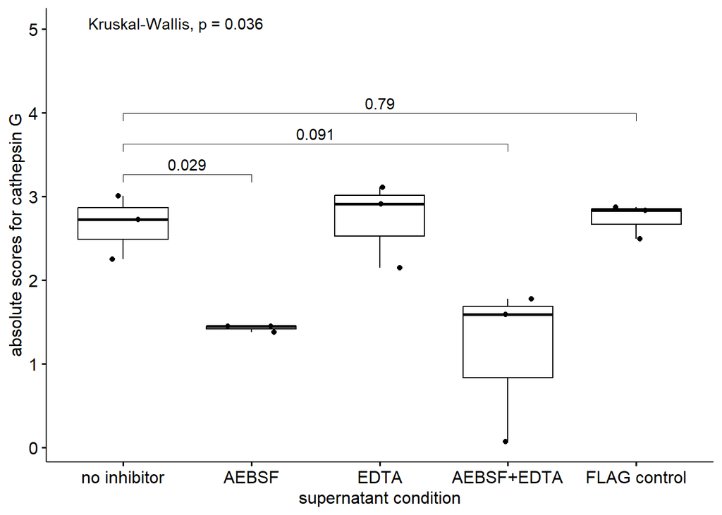

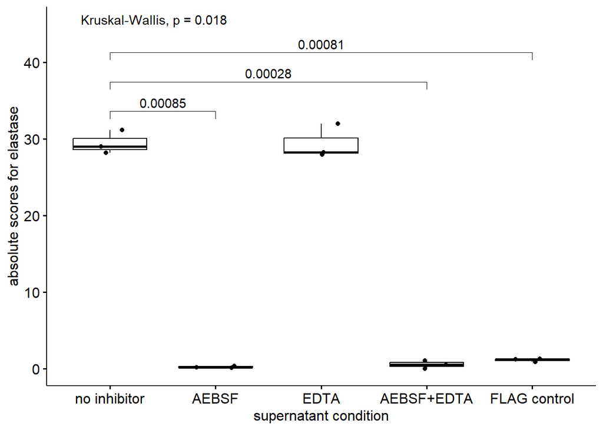

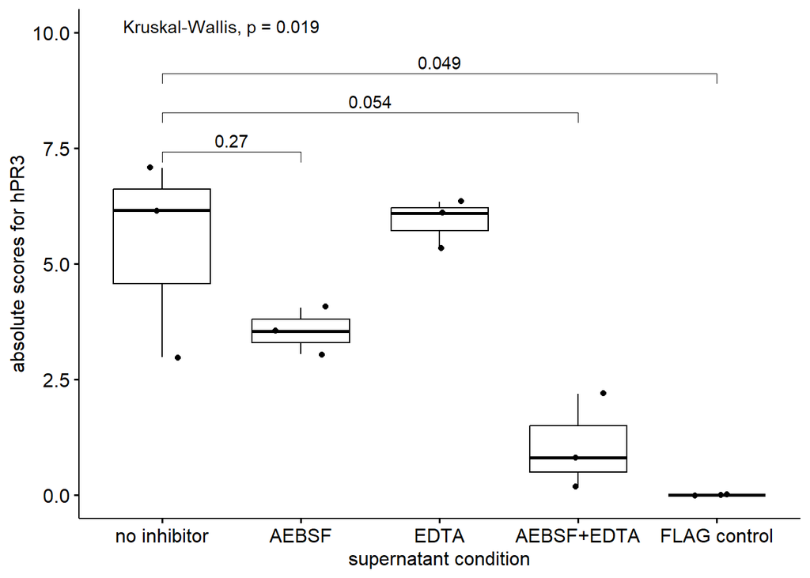

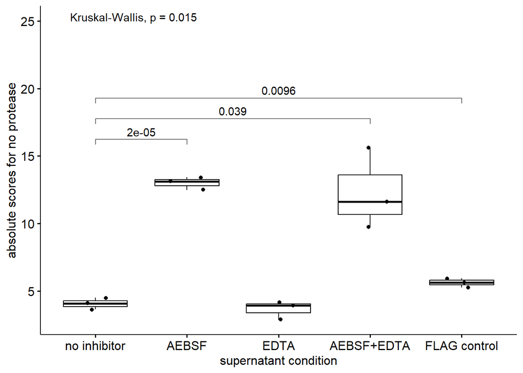

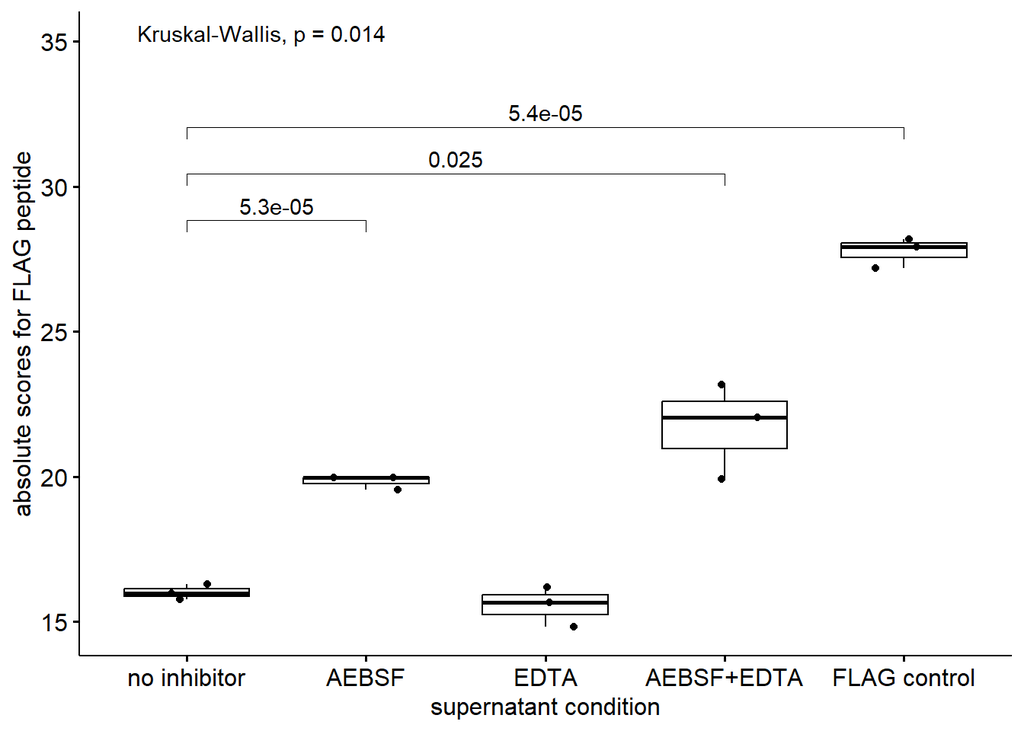

```r
conditions <- c("cathepsin_G", "elastase", "hPR3", "no_protease", "FLAG_peptide")
names = c("cathepsin G", "elastase", "hPR3", "no protease", "FLAG peptide")
condition_comparisons <- list( c("no inhibitor", "AEBSF"), c("no inhibitor", "AEBSF+EDTA"), c("no inhibitor", "FLAG control") )
graph_scale = c(5, 45, 10, 25, 35) #scale graph to fit y-axis

for(i in 1:length(conditions)){
  box_plot <- ggboxplot(cibersort_absolute, x = "Condition", y = conditions[i], add = "jitter") +
  labs(x = "supernatant condition", y = paste0("absolute scores for ", names[i])) +
  stat_compare_means(comparisons = condition_comparisons, method = "t.test") +
  stat_compare_means(label.y = graph_scale[i])
  show(box_plot)
}
```